# Workshop part 1

# Set up

First, read in the data.

```r
data <- read.csv("C:/Users/u249135/OneDrive - Baylor College of Medicine/Teaching Materials/R-workshop/Workshop/Stool4TB Database for Abi.csv")
colnames(data)[colnames(data) == "X...record_id"] <- "record_id"
```

We’ll use `ggplot2` and `dplyr` today. We need to read in the `tidyverse` package (remember, `ggplot2` and `dplyr` are bundled in the `tidyverse` package) to use them.

```r
library(tidyverse)
```

```r
### Create the variable for age
data <- data%>%
  ### Convert the dates to a date data type
  mutate(rf_enroll_date = ymd(rf_enroll_date))%>%
  mutate(rf_dob = ymd(rf_dob))%>%
  mutate(date_diff = time_length(interval(rf_dob, rf_enroll_date), unit = "years"))%>%
  mutate(date_diff = floor(date_diff))%>%
  mutate(age = ifelse(is.na(date_diff), rf_age, date_diff))
```

We are just using the baseline data, so filter to the baseline time point.

```r
data <- data%>%
  filter(redcap_event_name == "Baseline")
```

# t-test

Today, we’re going to use t-tests to compare two independent groups. However, t-tests can also be used for paired data.

Let’s investigate whether there is a **statistically significant difference** in respiratory rate at baseline by gender among children <= 8.

There are some assumptions that we need to check in order to conduct this test.

## Step 1. Check the assumptions

Is the data normally distributed?

We need to check that in each group **each group** (males and females <= 8) the respiratory rate is normally distributed.

To check this, we are going to plot a histogram for each group.

We could also check this using the Shapiro-Wilk test; please see steps for this in the “Notes” section below.

First, let’s create some subsets.

```r
### Create a subset for children
children_subset <- data%>%
  filter(age <= 8)%>%
  ### Remove the 4 participants who are missing this variable
  filter(!is.na(bf_respiratoryrate))
### Create subsets by gender
female_subset <- data%>%
  filter(rf_gender == "Female")%>%
  filter(age <= 8)%>%
  ### There are 3 NA values; remove them here
  filter(!is.na(bf_respiratoryrate))
male_subset <- data%>%
  filter(rf_gender == "Male")%>%
  filter(age <= 8)%>%
  ### There is 1 NA value; remove it here
  filter(!is.na(bf_respiratoryrate))
```

Use `ggplot2()` to create a histogram of the `bf_respiratoryrate` variable for each subset.

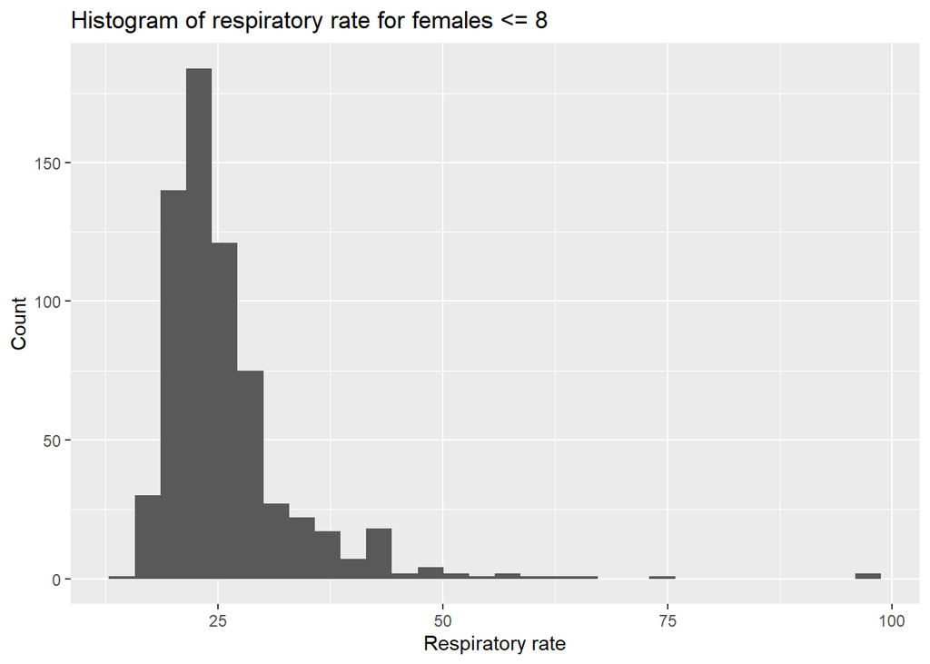

```r
### Females
ggplot(data = female_subset, aes(x = bf_respiratoryrate))+
  geom_histogram()+
  labs(x = "Respiratory rate",
       y = "Count",
       title = "Histogram of respiratory rate for females <= 8")
```

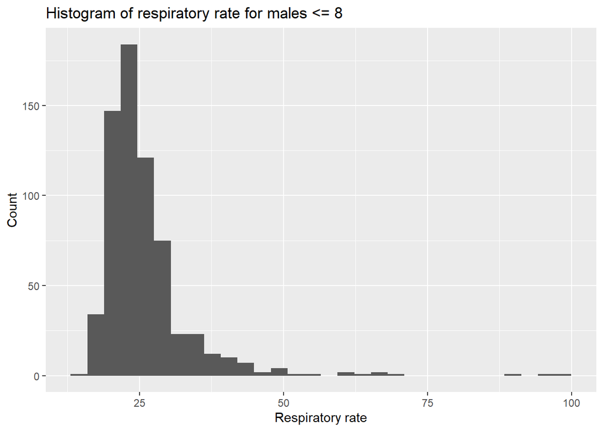

```r
### Males
ggplot(data = male_subset, aes(x = bf_respiratoryrate))+
  geom_histogram()+
  labs(x = "Respiratory rate",
       y = "Count",
       title = "Histogram of respiratory rate for males <= 8")
```

Each of these distributions are **skewed to the right**. Most respiratory rates are less than 50, however some participants have respiratory rates that approach 100.

The assumptions of normality is **not met**. If we follow the flow-chart that Zanele shared, this means that we need to conduct a **Wilcoxon test** rather than a **t-test**. Please reference the “Notes” section for code for a t-test.

## Step 2. Conduct the test

We are going to use the `wilcox.test()` function. This function takes `data` as an argument.

We’re going to use the *children_subset* as the data. Remember, this is the subset we created that is children <=8 at baseline who are not missing the `bf_respiratoryrate` variable.

After the data argument, we specify `bf_respiratoryrate ~ rf_gender`. The numeric variable always goes first, followed by the tilde (~) symbol, followed by the binary categorical variable. This can be read as “compare the variable for respiratory rate **by** gender”.

What’s going on behind the scenes here?

The function:

1. **Splits** the `bf_respiratoryrate` values into two groups based on `rf_gender`
2. **Ranks** all the values (from lowest to highest), ignoring group membership
3. **Compares** the sum of ranks between the two groups
4. Returns a **p-value** that tests whether the distributions of `bf_respiratoryrate` differ between the two `rf_gender` groups

This test is non-parametric, meaning it does **not assume a normal distribution** of the outcome variable. It’s useful when the outcome is skewed, ordinal, or contains outliers.

```r
wilcox.test(data = children_subset,
            bf_respiratoryrate ~ rf_gender)
```

```
##
##  Wilcoxon rank sum test with continuity correction
##
## data:  bf_respiratoryrate by rf_gender
## W = 222421, p-value = 0.3116
## alternative hypothesis: true location shift is not equal to 0
```

## Step 3. Interpret the results

The p-value is 0.3116. This is greater than 0.05. Therefore, we do **not** have evidence to reject the null hypothesis that the distribution of the two groups is the same. We cannot conclude a difference in respiratory rates between genders.

# Chi-squared test

Let’s consider just people living with HIV. Suppose we want to see if there’s an association between having a CD4 count <= 200 and age.

Chi-squared tests require two categorical variables. Right now, CD4 count and age are both numeric. Let’s create two new categorical variables.

To start, create a variable for age that is categorical.

```r
data <- data%>%
   ### Create a binary variable from the age variable
  mutate(age_cat = ifelse(age <= 8, "0-8", "15 and older"))
```

In order to create a subset of just people living with HIV, first investigate the `bf_hivstatus` variable.

```r
### First, create a subset of just people with HIV
table(data$age_cat, data$bf_hivstatus)
```

```
##
##                    Negative Positive Unknown
##   0-8            1      864       82     370
##   15 and older 707        0        0       0
```

Note that the `bf_hivstatus` variable is just for the 0-8 age category. All adults are living with HIV, however they have a blank value (““) for this variable. Let’s populate the missing values here with”Positive”.

```r
data <- data%>%
  ### Create a new variable, "hiv_status"

  ### When the participant is in the 15 and older category AND the HIV status is missing, the value is positive

  mutate(hiv_status = case_when(age_cat == "15 and older" & bf_hivstatus == "" ~ "Positive",
  ### When that condition is NOT met (so for all the participants in the 0-8 category), retain the value of the bf_hivstatus variable
                                TRUE ~ bf_hivstatus))
```

```r
table(data$hiv_status, data$bf_hivstatus, exclude = NULL)%>%addmargins()
```

```
##
##                 Negative Positive Unknown  Sum
##               1        0        0       0    1
##   Negative    0      865        0       0  865
##   Positive  707        0       82       0  789
##   Unknown     0        0        0     370  370
##   Sum       708      865       82     370 2025
```

The **rows** are the newly created variable, `hiv_status`. The **columns** are the original variable, `bf_hivstatus`. So, 707 values that were originally missing (““) are now”Positive”. We still have 1 missing the HIV status, though they are a child.

```r
### Filter to all people living with HIV
hiv_subset <- data%>%
  filter(hiv_status == "Positive")
```

Let’s do a quick check - are any people living with HIV missing the CD4 count? We’re going to have to do something with this variable. When we use the `head()` function to take a look at the first few rows of the data, we can see that there is a variable for CD4 result performed at the visit (`bf_cd4result`) and CD4 from the previous six months (`bf_recentcd4`).

```r
hiv_subset%>%
  select(record_id, bf_cd4result, bf_recentcd4)%>%
  head()
```

```
##   record_id bf_cd4result bf_recentcd4
## 1         1          537          537
## 2         2                      1015
## 3         3                       457
## 4         4          467
## 5         5          897
## 6         6          436
```

Let’s create a new variable - `composite_cd4` - that is the CD4 from the current visit if the data is available, and the CD4 from the past 6 months if there is no data from the current visit.

First, let’s ensure that the data is numeric. Taking a look, it appears that this variable is a character data type.

```r
str(hiv_subset$bf_cd4result)
```

```
##  chr [1:789] "537" "" "" "467" "897" "436" "659" "360" "" "657" "709" "" "" ...
```

```r
str(hiv_subset$bf_recentcd4)
```

```
##  chr [1:789] "537" "1015" "457" "" "" "" "" "" "674" "" "" "14" "653" "124" ...
```

And, taking a look, it appears that some values include characters. When we try and convert to a numeric, anything with a character will be NA, even if we may want to retain any relevant information.

```r
unique(hiv_subset$bf_recentcd4) ### This looks okay
```

```
##   [1] "537"   "1015"  "457"   ""      "674"   "14"    "653"   "124"   "342"
##  [10] "1150"  "1235"  "532"   "543"   "627"   "309"   "681"   "682"   "487"
##  [19] "894"   "685"   "654"   "698"   "468"   "711"   "541"   "867"   "1199"
##  [28] "769"   "752"   "539"   "644"   "683"   "547"   "438"   "471"   "1237"
##  [37] "753"   "672"   "190"   "1115"  "368"   "456"   "195"   "512"   "703"
##  [46] "794"   "1320"  "1044"  "840"   "630"   "459"   "382"   "401"   "1585"
##  [55] "1051"  "885"   "1274"  "206"   "880"   "810"   "492"   "873"   "1057"
##  [64] "3"     "8"     "1407"  "888"   "724"   "637"   "320"   "745"   "801"
##  [73] "639"   "458"   "762"   "909"   "624"   "360"   "1170"  "1371"  "881"
##  [82] "428"   "352"   "502"   "678"   "460"   "381"   "558"   "956"   "516"
##  [91] "261"   "93"    "577"   "1101"  "529"   "1019"  "712"   "1731"  "648"
## [100] "989"   "365"   "1273"  "556"   "659"   "357"   "913"   "572"   "688"
## [109] "1047"  "790"   "2443"  "926"   "734"   "430"   "578"   "638"   "846"
## [118] "334"   "850"   "583"   "744"   "581"   "510"   "473"   "78"    "423"
## [127] "548"   "1603"  "157"   "99"    "433"   "461"   "114"   "545"   "414"
```

[output cut: 20 more lines]

```r
unique(hiv_subset$bf_cd4result) ### I'm seeing "discarded" here
```

```
##   [1] "537"        ""           "467"        "897"        "436"
##   [6] "659"        "360"        "657"        "709"        "385"
##  [11] "571"        "879"        "536"        "653"        "1124"
##  [16] "351"        "774"        "618"        "756"        "542"
##  [21] "988"        "377"        "65"         "738"        "519"
##  [26] "1008"       "498"        "785"        "700"        "1346"
##  [31] "944"        "270"        "462"        "175"        "904"
##  [36] "413"        "687"        "193"        "480"        "557"
##  [41] "460"        "650"        "648"        "645"        "758"
##  [46] "1261"       "417"        "1117"       "338"        "547"
##  [51] "225"        "425"        "1435"       "760"        "662"
##  [56] "630"        "347"        "553"        "494"        "530"
##  [61] "558"        "124"        "312"        "577"        "873"
##  [66] "discarded " "51"         "261"        "539"        "712"
##  [71] "989"        "1047"       "725"        "59"         "540"
```

[output cut: 42 more lines]

```r
### Convert "discarded" to ""
hiv_subset$bf_cd4result[hiv_subset$bf_cd4result == "discarded"] <- ""
```

```r
### Convert each of the CD4 variables to be a numeric data type
hiv_subset <- hiv_subset%>%
  mutate(bf_cd4result = as.numeric(bf_cd4result))%>%
  mutate(bf_recentcd4 = as.numeric(bf_recentcd4))
### Anything that was originally "" will be converted to NA - in our case, that is okay
```

```r
hiv_subset <- hiv_subset%>%
  mutate(composite_cd4 = ifelse(is.na(bf_cd4result), bf_recentcd4, bf_cd4result))
```

```r
### Let's take another peek at the data
hiv_subset%>%
  select(record_id, composite_cd4, bf_recentcd4, bf_cd4result)%>%
  head() ### This looks good!
```

```
##   record_id composite_cd4 bf_recentcd4 bf_cd4result
## 1         1           537          537          537
## 2         2          1015         1015           NA
## 3         3           457          457           NA
## 4         4           467           NA          467
## 5         5           897           NA          897
## 6         6           436           NA          436
```

Are any participants living with HIV still missing CD4 count?

```r
hiv_subset%>%
  filter(is.na(composite_cd4))%>%
  nrow() ### 96 participants are missing CD4
```

```
## [1] 96
```

```r
### For our purposes, filter to exclude these participants in order to compare CD4 to age
hiv_subset <- hiv_subset%>%
  filter(!is.na(composite_cd4))

### Create a categorical variable for CD4
hiv_subset <- hiv_subset%>%
  mutate(cd4_category = ifelse(composite_cd4 <= 200, "CD4 <= 200", "CD4 > 200"))
```

```r
table(hiv_subset$age_cat, hiv_subset$cd4_category, exclude = NULL)%>%
  addmargins()
```

```
##
##                CD4 <= 200 CD4 > 200 Sum
##   0-8                   2        54  56
##   15 and older         85       552 637
##   Sum                  87       606 693
```

## Step 1. Check the assumptions

The assumption for the chi-squared test is that the **expected counts** are all greater than or equal to 5.

We need to calculate the expected counts for each cell in the table, and each needs to be >= 5 in order for the assumption to be met.

The formula for this is: $\frac{\text{Row total} * \text{Column total}}{\text{Total number of participants}}$

Let’s do these calculations!

CD4 <= 200 and 0-8:

```r
56 * 87 / 693
```

```
## [1] 7.030303
```

CD4 <= 200 and 15 and older:

```r
637 * 87 / 693
```

```
## [1] 79.9697
```

CD4 > 200 and 0-8:

```r
56 * 606 / 693
```

```
## [1] 48.9697
```

CD4 > 200 and 15 and older:

```r
637 * 606 / 693
```

```
## [1] 557.0303
```

All of the **expected values** are greater than 5, so the assumptions are met and we can proceed with the chi-squared test.

## Step 2. Conduct the test

We use the `chisq.test()` function to conduct a chi-squared test.

As an argument to the function, we include a table with the categorical CD4 variable, as well as the categorical age variable.

**It is super important that we don’t include addmargins() to the table! This will give the incorrect result**

```r
chisq.test(table(hiv_subset$cd4_category, hiv_subset$age_cat))
```

```
##
##  Pearson's Chi-squared test with Yates' continuity correction
##
## data:  table(hiv_subset$cd4_category, hiv_subset$age_cat)
## X-squared = 3.6319, df = 1, p-value = 0.05668
```

## Step 3. Interpret the results

The p-value is 0.05668. This is super close to being less than 0.05, however it is still greater than 0.05. Therefore, we do not have evidence to reject the null hypothesis that there is no association between age and CD4.

# Correlation

Let’s investigate the correlation between weight and height among adults.

First, create an adult subset.

```r
adult_subset <- data%>%
  filter(age_cat == "15 and older")
```

## Step 1. Check the assumptions

Let’s check that each variable is normally distributed.

First, is either weight or height missing for any participant?

```r
### Participants missing weight
adult_subset%>%
  filter(is.na(bf_weight))%>%
  select(record_id, bf_weight)
```

```
##   record_id bf_weight
## 1 4TB-2-098        NA
```

```r
### Participants missing height
adult_subset%>%
  filter(is.na(bf_height))%>%
  select(record_id, bf_height)
```

```
## [1] record_id bf_height
## <0 rows> (or 0-length row.names)
```

```r
### 1 participant is missing weight. Remove the participant in order to calculate the correlation
adult_subset <- adult_subset%>%
  filter(!is.na(bf_weight))
```

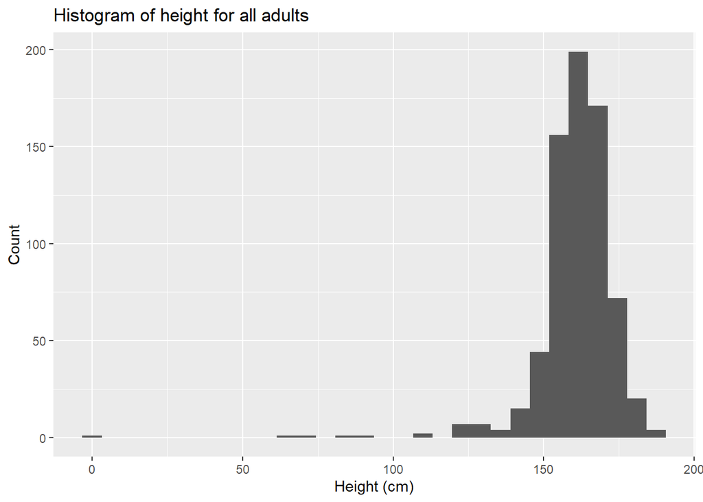

```r
ggplot(data = adult_subset, aes(x = bf_height))+
  geom_histogram()+
  labs(x = "Height (cm)",
       y = "Count",
       title = "Histogram of height for all adults")
```

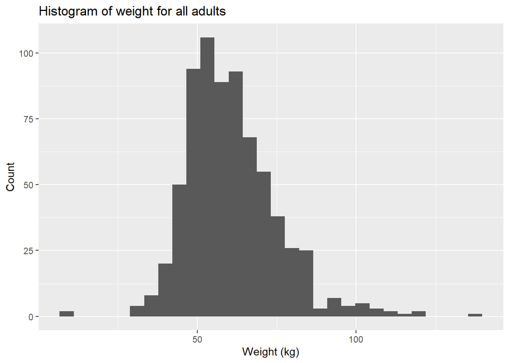

```r
ggplot(data = adult_subset, aes(x = bf_weight))+
  geom_histogram()+
  labs(x = "Weight (kg)",
       y = "Count",
       title = "Histogram of weight for all adults")
```

The weight variable appears right-skewed, with most participants weighing less than 100 kg but a few outliers above 100 kg.

The height variable appears left-skewed, with most participants 150 cm or taller, but some values below 100 cm.

Due to the non-normal distribution and presence of potential outliers, Spearman’s rank correlation is more appropriate than Pearson’s correlation, as it does not assume normality and is less sensitive to outliers.

## Step 2. Conduct the test

First, let’s visualize the relationship between the two variables.

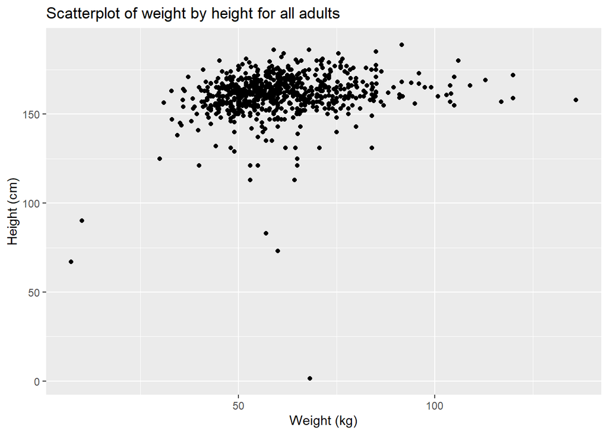

```r
ggplot(data = adult_subset, aes(x = bf_weight, y = bf_height))+
  geom_point()+
  labs(x = "Weight (kg)",
       y = "Height (cm)",
       title = "Scatterplot of weight by height for all adults")
```

Looking at the scatter plot, there is not really a clear relationship between height and weight among the adults.

```r
cor(adult_subset$bf_weight, adult_subset$bf_height, method = "spearman")
```

```
## [1] 0.194847
```

## Step 3. Interpret the results

Spearman’s correlation coefficient can range from -1 to 1. 0.194847 indicates a weak, positive relationship - which aligns with scatter plot we made.

# ANOVA

The last test we’re going to focus on is the ANOVA test!

The ANOVA test is used to compare the mean of more than 2 groups.

As an exploration, let’s investigate whether there are any differences in the CD4 count between countries, using the same `hiv_subset` that we created for the chi-squared test.

## Step 1. Check the assumptions

An assumption of the ANOVA is that the data within each group (or category) are approximately normally distributed.

To check this, let’s split our data into three subsets — one for each country — and look at their distributions. This helps us see if the normality assumption is reasonable before conducting the ANOVA.

```r
### Create subsets for each country
eswatini_subset <- hiv_subset%>%
  filter(rf_country == "Eswatini")
mozambique_subset <- hiv_subset%>%
  filter(rf_country == "Mozambique")
uganda_subset <- hiv_subset%>%
  filter(rf_country == "Uganda")
```

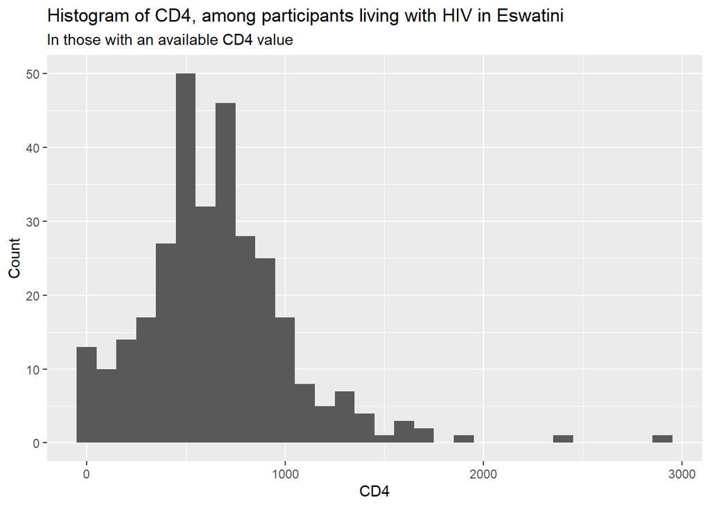

```r
### Eswatini
ggplot(data = eswatini_subset, aes(x = composite_cd4))+
  geom_histogram()+
  labs(x = "CD4",
       y = "Count",
       title = "Histogram of CD4, among participants living with HIV in Eswatini",
       subtitle = "In those with an available CD4 value")
```

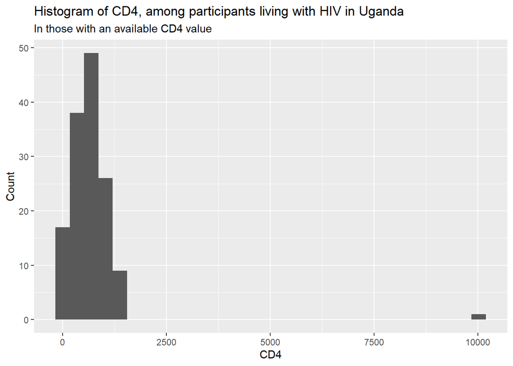

```r
### Uganda
ggplot(data = uganda_subset, aes(x = composite_cd4))+
  geom_histogram()+
  labs(x = "CD4",
       y = "Count",
       title = "Histogram of CD4, among participants living with HIV in Uganda",
       subtitle = "In those with an available CD4 value")
```

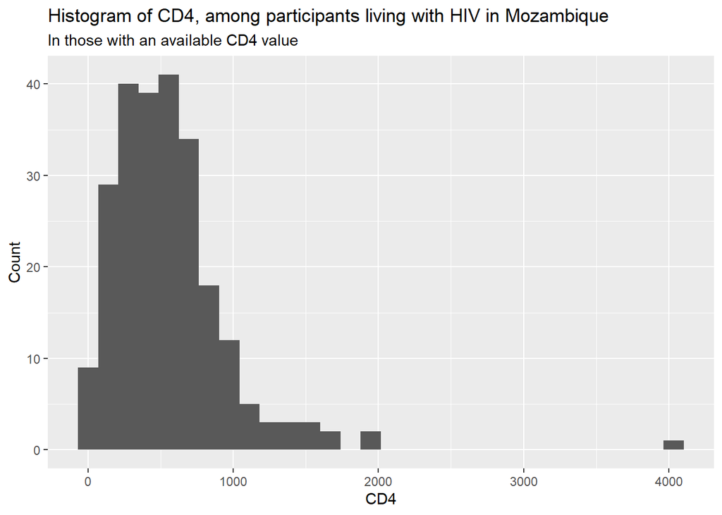

```r
### Mozambique
ggplot(data = mozambique_subset, aes(x = composite_cd4))+
  geom_histogram()+
  labs(x = "CD4",
       y = "Count",
       title = "Histogram of CD4, among participants living with HIV in Mozambique",
       subtitle = "In those with an available CD4 value")
```

All of the distributions appear to be skewed to the right. Most participants have a CD4 value less than 1000, however some exceed 2000.

Therefore, the assumption of normality is **not met** and we will proceed with the Kruskal-Wallis test.

We could also create side-by-side boxplots to visualize this data.

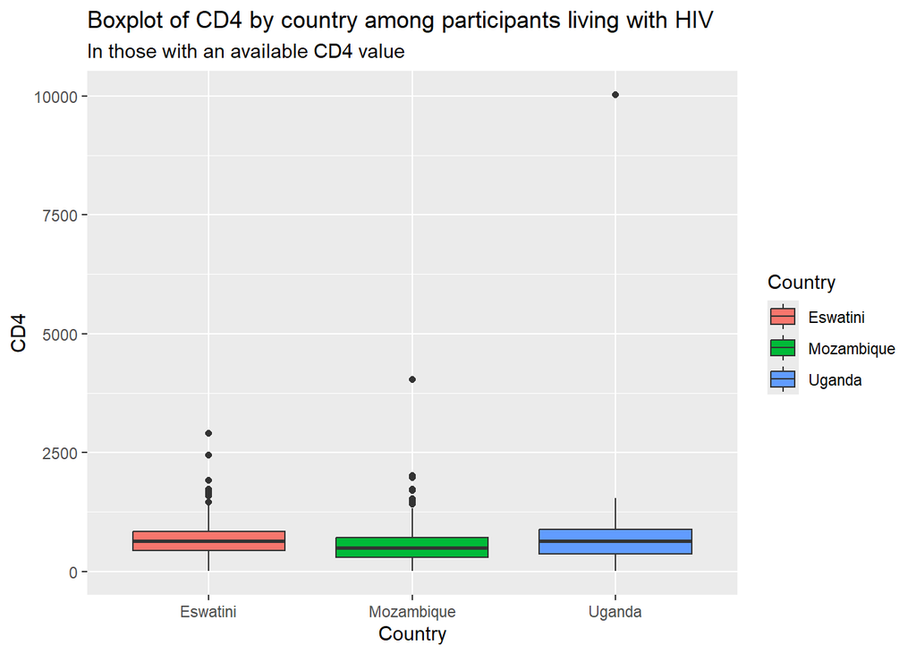

```r
ggplot(data = hiv_subset, aes(x = rf_country, y = composite_cd4, fill = rf_country))+
  geom_boxplot()+
  labs(x = "Country",
       y = "CD4",
       title = "Boxplot of CD4 by country among participants living with HIV",
       subtitle = "In those with an available CD4 value",
       fill = "Country")
```

And, we may be interested in calculating the median and IQR of the CD4 values for each group.

```r
### Median
hiv_subset%>%
  group_by(rf_country)%>%
  summarize(median_cd4 = median(composite_cd4))
```

```
## # A tibble: 3 × 2
##   rf_country median_cd4
##   <chr>           <dbl>
## 1 Eswatini         638.
## 2 Mozambique       491
## 3 Uganda           642.
```

```r
### IQR
hiv_subset%>%
  group_by(rf_country)%>%
  summarize(iqr_cd4 = IQR(composite_cd4))
```

```
## # A tibble: 3 × 2
##   rf_country iqr_cd4
##   <chr>        <dbl>
## 1 Eswatini      406.
## 2 Mozambique    423
## 3 Uganda        523.
```

It appears that the median CD4 value for Mozambique is lower than the other two sites. And, Uganda has the higher inner-quartile range among the three sites.

## Step 2. Conduct the test

```r
kruskal.test(data = hiv_subset,
             composite_cd4 ~ rf_country)
```

```
##
##  Kruskal-Wallis rank sum test
##
## data:  composite_cd4 by rf_country
## Kruskal-Wallis chi-squared = 18.978, df = 2, p-value = 7.569e-05
```

## Step 3. Interpret the results

The Kruskal-Wallis test indicated a statistically significant difference in CD4 values between sites (p < 0.05). This suggests that at least one site differs in CD4 distribution from the others

One important note is that both the ANOVA and the Kruskal-Wallis test can indicate whether there are differences between the groups, though not what **specific** groups are different. Please refer to the notes section for how to determine which groups exactly are different.

# Notes

We do not have time to cover every detail outlined in the presentation. Please refer to this section for more details.

## t-test

Remember that for a t-test, we need to check a few assumptions. We did that above by looking at histograms of the data. However, there are some tests we conduct to investigate whether the data for each group is normal and has equal variances.

### Normality

To test normality, we can use the `shapiro.test()` function.

As an example, we investigated the normality of respiratory rate by gender for children in our t-test above.

We need to conduct the Shapiro-Wilk test for each group - males and females. Let’s start by creating subsets for each group.

```r
### Create subsets by gender
female_subset <- data%>%
  filter(redcap_event_name == "Baseline")%>%
  filter(rf_gender == "Female")%>%
  filter(age <= 8)
male_subset <- data%>%
  filter(redcap_event_name == "Baseline")%>%
  filter(rf_gender == "Male")%>%
  filter(age <= 8)
### Apply the Shapiro-Wilk test to each subset
shapiro.test(female_subset$bf_respiratoryrate)
```

```
##
##  Shapiro-Wilk normality test
##
## data:  female_subset$bf_respiratoryrate
## W = 0.7263, p-value < 2.2e-16
```

```r
shapiro.test(male_subset$bf_respiratoryrate)
```

```
##
##  Shapiro-Wilk normality test
##
## data:  male_subset$bf_respiratoryrate
## W = 0.67883, p-value < 2.2e-16
```

How do we interpret the results?

The **null hypothesis** is that the data is normally distributed. For each subset, the p-value is **less than 0.05**. In fact, it is so small that R reports *p-value < 2.2e-16* rather than the exact p-value.

Because our p-value is less than 0.05, we reject the null hypothesis that the data is normally distributed. Therefore, the assumption of normality is not met and we should proceed with with **Wilcoxon rank-sum test**. Note that this is the same conclusion we reached by looking at the histograms of the data.

Here is a reference on this test and more explanation on the code: https://www.sthda.com/english/wiki/normality-test-in-r

For a lot more detail on this test - and also on qqplots, another way we can assess normality - please reference this video: https://www.youtube.com/watch?v=eh9eYLBecWk

### Equal variances

Another assumption for the t-test is that the two groups have equal variances.

To check this, you can use the Levene test. The code for the Levene test is in the `car` package. Let’s install the package (remember, we just need to do this once) and use the `library()` function to read in the package.

```r
### install.packages("car")
library(car)
```

We will be using the `leveneTest` function from the `car` package. Rather than two subsets, the `leveneTest` function uses the following syntax:

**leveneTest(numeric variable ~ categorical data, data = data_subset)**

So, we’re going to use the **children_subset** we created above.

```r
leveneTest(bf_respiratoryrate ~ rf_gender,
           data = children_subset)
```

```
## Levene's Test for Homogeneity of Variance (center = median)
##         Df F value Pr(>F)
## group    1  0.0972 0.7553
##       1311
```

How do we interpret these results? The null hypothesis for this test is that the variance of the two groups are equal. Our p-value is **greater than 0.05**. Therefore, we have no evidence to reject the null hypothesis that the variance of the two groups are equal.

More information on the Levene test can be found here: https://www.sthda.com/english/wiki/compare-multiple-sample-variances-in-r

### t.test() function

In the above example, we concluded that the data was not normally distributed, so we moved forward with a Wilcoxon rank-sum test.

However, this is a resource to use if the assumptions are met to use a t-test (the “2-sample t-test” section). This is also helpful for more information on a 1-sample t-test:

https://bookdown.org/ndphillips/YaRrr/t-test-t-test.html

```r
### You can also look at the help documentation for this function
?t.test()
```

## Chi-squared

When we checked the assumptions for the test above, we found that each of the expected counts were greater than or equal to 5 so we moved forward with the chi-squared test.

However, if we would have found that any of the expected counts were less than 5, the assumptions for the test would not have been met and we would have proceeded with Fisher’s exact test.

Here is more information on Fisher’s exact test if you ever need to use this in the future.

```r
?fisher.test()
```

## Correlation

One argument of the `cor()` function is `method`.

By looking at the results of `?cor()`, we can see that there are 3 methods - pearson, kendall, and spearman.

We used spearman above, because the assumptions for using the pearson method were not met. However, in the future, you can change `method = "pearson"` if the assumptions for performing the test are met.

The kendall method is similar to the spearman method, however it is more robust to smaller sample sizes.

## ANOVA

If the assumptions are met to conduct an ANOVA, rather than a Kruskal-Wallis test, the following function can be used:

```r
?aov()
```

Determining the differences between groups after an ANOVA or Kruskal-Wallis test has been conducted is called **post-hoc analysis**.

For an ANOVA test, here is a good resource: https://www.r-bloggers.com/2021/08/how-to-perform-tukey-hsd-test-in-r/

For the Kruskal-Wallis test, here is a good resource: https://www.statology.org/dunns-test-in-r/